# Talk Results Companion: V4 Simplified Adherence Simulation

Figure and Table Bank for Presentation

Author

HIV Adherence Simulation Project

Published

March 30, 2026

# 1 Purpose

This document collects talk-ready figures and tables from the V4 simplified adherence simulation. It demonstrates the full pipeline: DGP overview, naive analyses (biased), LTMLE on categorised adherence, LMTP on continuous PDC, and matched-adherence drug comparisons.

# 2 Oracle and DGP Overview

## 2.1 Generate cohort and oracle grid

## 2.2 Oracle forgiveness curves

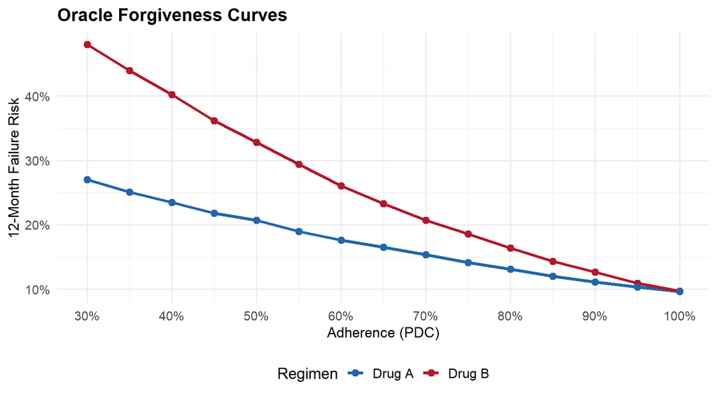

Figure 1: True cumulative failure risk by adherence level and drug. Drug A shows greater forgiveness at sub-optimal adherence.

- At high adherence ($\geq 90\%$), both drugs perform similarly
- At low adherence ($\leq 50\%$), Drug A failure risk is substantially lower
- This gap is the **forgiveness differential**

## 2.3 Oracle risk table

Table 1: Oracle risks and risk differences at selected PDC levels

| pdc | Drug B | Drug A | RD |
| --- | --- | --- | --- |
| 0.3 | 0.480 | 0.270 | -0.209 |
| 0.4 | 0.402 | 0.234 | -0.167 |
| 0.5 | 0.328 | 0.207 | -0.121 |
| 0.6 | 0.261 | 0.176 | -0.085 |
| 0.7 | 0.207 | 0.154 | -0.053 |
| 0.8 | 0.164 | 0.131 | -0.033 |
| 0.9 | 0.126 | 0.111 | -0.015 |
| 1.0 | 0.097 | 0.097 | -0.001 |

## 2.4 DGP summary

Table 2: Simulated cohort characteristics

| Feature | Value |
| --- | --- |
| Sample size | 5,000 |
| Follow-up | 12 months |
| Block size | 90 days (quarterly) |
| Drug A (%) | 49.2 |
| Mean PDC (Drug A) | 0.681 |
| Mean PDC (Drug B) | 0.744 |
| Cumulative failure (%) | 18.5 |

# 3 Why Naive Analyses Fail

Table 3: Naive analysis: failure rates by observed mean PDC stratum and drug

| Drug | Stratum | Risk | N |
| --- | --- | --- | --- |
| Drug A | Low | 0.229 | 944 |
| Drug A | Mid | 0.143 | 1226 |
| Drug A | High | 0.082 | 291 |
| Drug B | Low | 0.368 | 581 |
| Drug B | Mid | 0.187 | 1348 |
| Drug B | High | 0.069 | 610 |

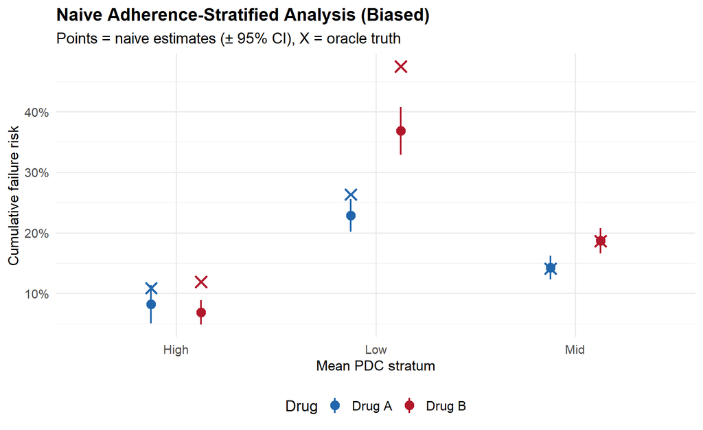

Figure 2: Naive failure rates (points) vs oracle truth (X) by adherence stratum and drug. Discrepancies reveal bias from time-dependent confounding.

# 4 Positivity and Support Diagnostics

## 4.1 PDC distribution by drug and block (Figure C)

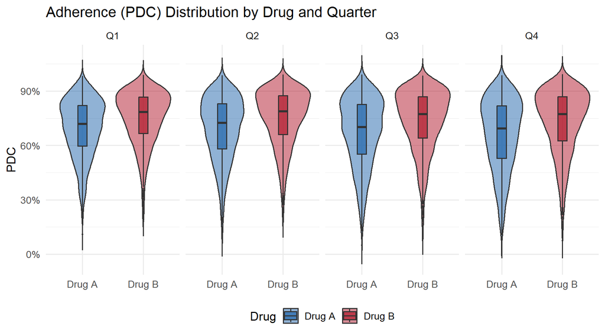

Figure 3: Adherence (PDC) distribution by drug and quarter. Violin + boxplots show the full distribution shape.

## 4.2 Support heatmap (Figure A)

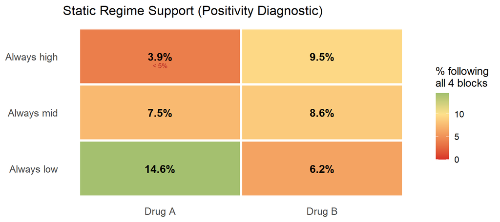

Figure 4: Proportion of subjects naturally following each static regime across all 4 blocks. Values below 5% are flagged — these regimes face positivity problems.

## 4.3 Detailed support diagnostics (Table A)

Table 4: Effective support diagnostics: per-block category frequencies, full-regime followers, and event counts

| Drug | Regime | Block_pcts | N_follow | Pct_follow | Events | Flag |
| --- | --- | --- | --- | --- | --- | --- |
| Drug B | always_high | 30% / 33% / 31% / 30% | 241 | 9.5% | 13 | OK |
| Drug B | always_mid | 48% / 44% / 43% / 43% | 219 | 8.6% | 37 | OK |
| Drug B | always_low | 22% / 23% / 26% / 28% | 157 | 6.2% | 75 | OK |
| Drug A | always_high | 17% / 20% / 19% / 18% | 96 | 3.9% | 10 | SPARSE |
| Drug A | always_mid | 48% / 43% / 42% / 38% | 185 | 7.5% | 26 | OK |
| Drug A | always_low | 35% / 36% / 39% / 43% | 359 | 14.6% | 103 | OK |

## 4.4 Estimand alignment: midpoint vs uniform oracle (Table B)

Table 5: Oracle under category midpoint vs uniform draws. Difference quantifies the effect of within-category variation.

| Drug | Category | Oracle_uniform | Oracle_midpoint | Difference |
| --- | --- | --- | --- | --- |
| Drug B | low | 0.4745 | 0.4546 | 0.0199 |
| Drug B | mid | 0.1864 | 0.1872 | -0.0009 |
| Drug B | high | 0.1174 | 0.1185 | -0.0011 |
| Drug A | low | 0.2629 | 0.2592 | 0.0037 |
| Drug A | mid | 0.1412 | 0.1407 | 0.0005 |
| Drug A | high | 0.1085 | 0.1096 | -0.0012 |

# 5 LTMLE Static Regime Results

## 5.1 Oracle values for category regimes

Oracle risks under static category regimes (two modes)

| Drug | Category | Oracle (uniform) | Oracle (midpoint) |
| --- | --- | --- | --- |
| Drug B | high | 0.1159 | 0.1173 |
| Drug B | mid | 0.1862 | 0.1839 |
| Drug B | low | 0.4755 | 0.4560 |
| Drug A | high | 0.1088 | 0.1080 |
| Drug A | mid | 0.1419 | 0.1421 |
| Drug A | low | 0.2635 | 0.2598 |

## 5.2 Fit LTMLE (GLM-based, clean setting)

Table 6: LTMLE estimates vs uniform oracle (clean setting, GLM nuisance)

| Drug | Category | LTMLE | SE | Oracle | Bias | Converged |
| --- | --- | --- | --- | --- | --- | --- |
| Drug B | high | 0.0925 | 0.0177 | 0.1159 | -0.0235 | TRUE |
| Drug B | low | 0.3549 | 0.0389 | 0.4755 | -0.1206 | TRUE |
| Drug B | mid | 0.1903 | 0.0216 | 0.1862 | 0.0040 | TRUE |
| Drug A | high | 0.1224 | 0.0269 | 0.1088 | 0.0136 | TRUE |
| Drug A | low | 0.2318 | 0.0211 | 0.2635 | -0.0317 | TRUE |
| Drug A | mid | 0.1258 | 0.0192 | 0.1419 | -0.0161 | TRUE |

## 5.3 Estimated vs oracle forgiveness curves (3-category)

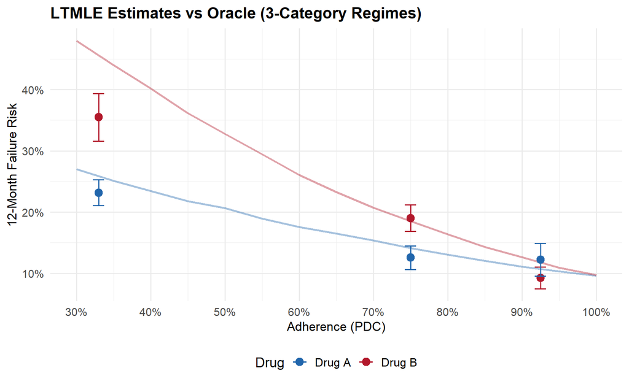

Figure 5: LTMLE estimates (3 broad categories) overlaid on oracle curves. Points at category midpoints.

## 5.4 Estimated vs oracle forgiveness curves (fine 10%-width bins)

```
Illustrative fine grid loaded: n=25000, seed=2026, 12/14 CIs cover oracle
```

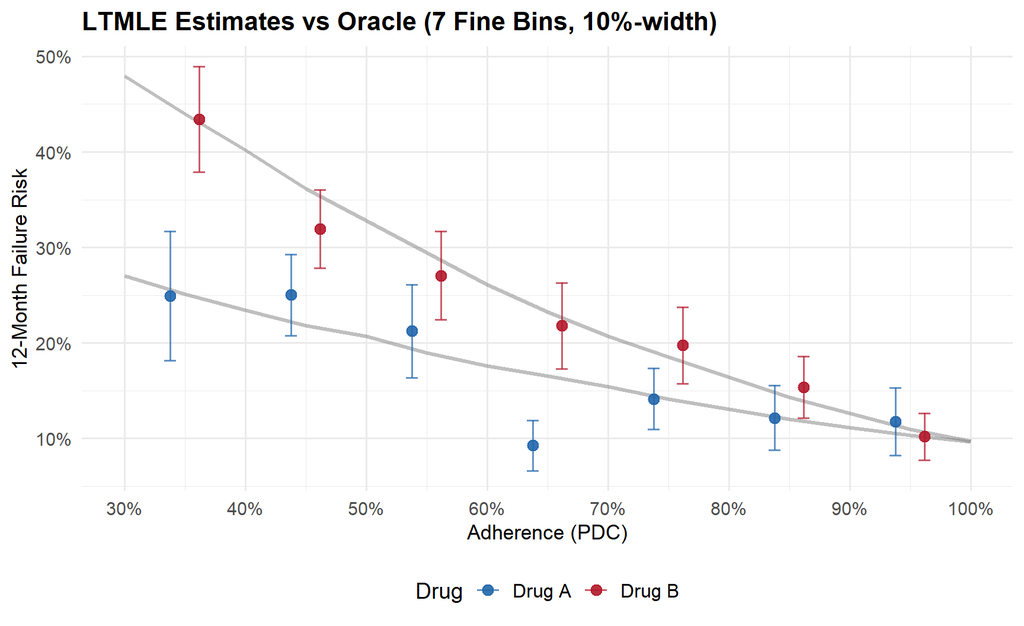

Figure 6: LTMLE fine-bin estimates (7 bins, 10%-width) overlaid on oracle forgiveness curves. Points are dodged slightly by drug for readability. Well-supported bins track the oracle; sparse bins show wider CIs.

Table 7: Fine-grid LTMLE: 7 bins by drug, with 95% CI coverage of oracle

| Drug | Bin | Midpoint | LTMLE | Oracle | Bias | SE | CI Covers |
| --- | --- | --- | --- | --- | --- | --- | --- |
| Drug B | 1 | 0.35 | 0.4341 | 0.4387 | -0.0046 | 0.0283 | Yes |
| Drug B | 2 | 0.45 | 0.3193 | 0.3629 | -0.0436 | 0.0210 | No |
| Drug B | 3 | 0.55 | 0.2704 | 0.2942 | -0.0239 | 0.0236 | Yes |
| Drug B | 4 | 0.65 | 0.2180 | 0.2331 | -0.0152 | 0.0230 | Yes |
| Drug B | 5 | 0.75 | 0.1974 | 0.1825 | 0.0149 | 0.0205 | Yes |
| Drug B | 6 | 0.85 | 0.1534 | 0.1422 | 0.0112 | 0.0165 | Yes |
| Drug B | 7 | 0.95 | 0.1018 | 0.1103 | -0.0085 | 0.0125 | Yes |
| Drug A | 1 | 0.35 | 0.2492 | 0.2515 | -0.0023 | 0.0346 | Yes |
| Drug A | 2 | 0.45 | 0.2504 | 0.2190 | 0.0313 | 0.0217 | Yes |
| Drug A | 3 | 0.55 | 0.2123 | 0.1904 | 0.0218 | 0.0248 | Yes |
| Drug A | 4 | 0.65 | 0.0925 | 0.1630 | -0.0705 | 0.0136 | No |
| Drug A | 5 | 0.75 | 0.1415 | 0.1409 | 0.0006 | 0.0163 | Yes |
| Drug A | 6 | 0.85 | 0.1214 | 0.1211 | 0.0003 | 0.0172 | Yes |
| Drug A | 7 | 0.95 | 0.1176 | 0.1048 | 0.0128 | 0.0182 | Yes |

# 6 LMTP Shift Results

## 6.1 Additive PDC shift (+10%)

Table 8: LMTP estimates: natural risk and +10% PDC shift, vs oracle

|  | Drug | Natural | Nat. Oracle | Nat. Bias | +10% Shift | Shift Oracle | Shift Bias |
| --- | --- | --- | --- | --- | --- | --- | --- |
| Drug B | Drug B | 0.2000 | 0.2068 | -0.0068 | 0.1401 | 0.1429 | -0.0028 |
| Drug A | Drug A | 0.1683 | 0.1676 | 0.0007 | 0.1407 | 0.1316 | 0.0091 |

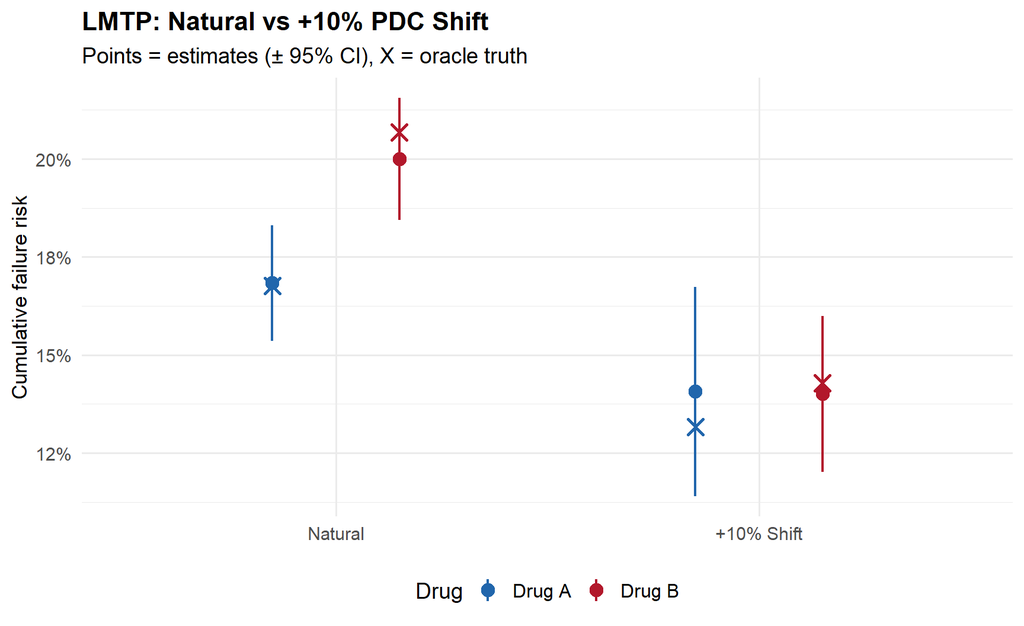

Figure 7: LMTP shift estimates (points ± 95% CI) vs oracle truth (X). Comparing natural risk to +10% PDC shift.

## 6.2 Shift distribution visualization (Figure D)

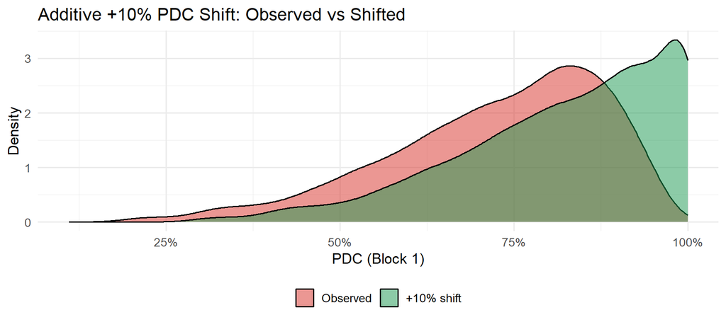

Figure 8: Observed vs +10% shifted PDC distribution. The shift stays within observed support.

# 7 Drug Comparison Under Matched Adherence

Table 9: Drug comparison under matched (Drug B) adherence distribution

| Estimand | Estimate | Oracle | SE | Bias |
| --- | --- | --- | --- | --- |
| Drug B risk (own adherence) | 0.2006 | 0.2092 | 0.0079 | -0.0086 |
| Drug A risk (under Drug B adherence) | 0.1363 | 0.1507 | 0.0079 | -0.0144 |
| Risk difference (Drug A - Drug B) | -0.0643 | -0.0585 | 0.0112 | -0.0058 |

## 7.1 Quantile-matched drug comparison: both directions

The quantile-matching approach maps one drug’s adherence distribution to the other’s, isolating the pharmacological effect from adherence differences.

Table 10: Quantile-matched drug comparison under both reference adherence distributions

| Direction | Estimate | Oracle | Bias |
| --- | --- | --- | --- |
| Under Drug B adherence: Drug B | 0.2006 | 0.2092 | -0.0086 |
| Under Drug B adherence: Drug A | 0.1363 | 0.1507 | -0.0144 |
| RD (A − B) under Drug B adherence | -0.0643 | -0.0585 | -0.0058 |
| Under Drug A adherence: Drug A | 0.1687 | 0.1657 | 0.0030 |
| Under Drug A adherence: Drug B | 0.2729 | 0.2422 | 0.0307 |
| RD (A − B) under Drug A adherence | -0.1043 | -0.0766 | -0.0277 |

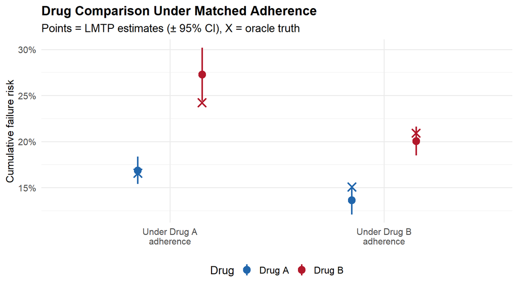

Figure 9: Drug comparison under matched adherence distributions. Points = LMTP estimates (± 95% CI), X = oracle truth. Under either drug’s adherence pattern, Drug A has lower failure risk.

- Under **either** drug’s adherence distribution, Drug A has lower failure risk
- This isolates the pharmacological forgiveness effect from adherence behavior differences
- The quantile-matching approach stays within observed support at each block

## 7.2 Adherence density plots: observed vs shifted

These density plots visualize the shift interventions applied in both the additive +10% shift and the quantile-matching analyses.

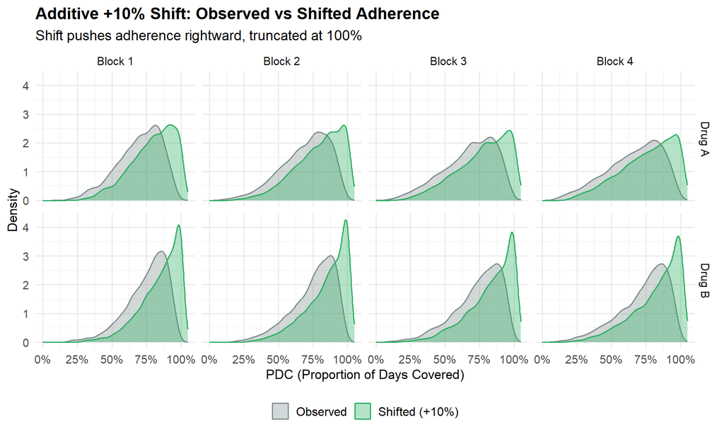

Figure 10: Observed vs shifted (+10 pp) adherence distributions by drug and block. The shift pushes the distribution rightward, truncating at 1.0.

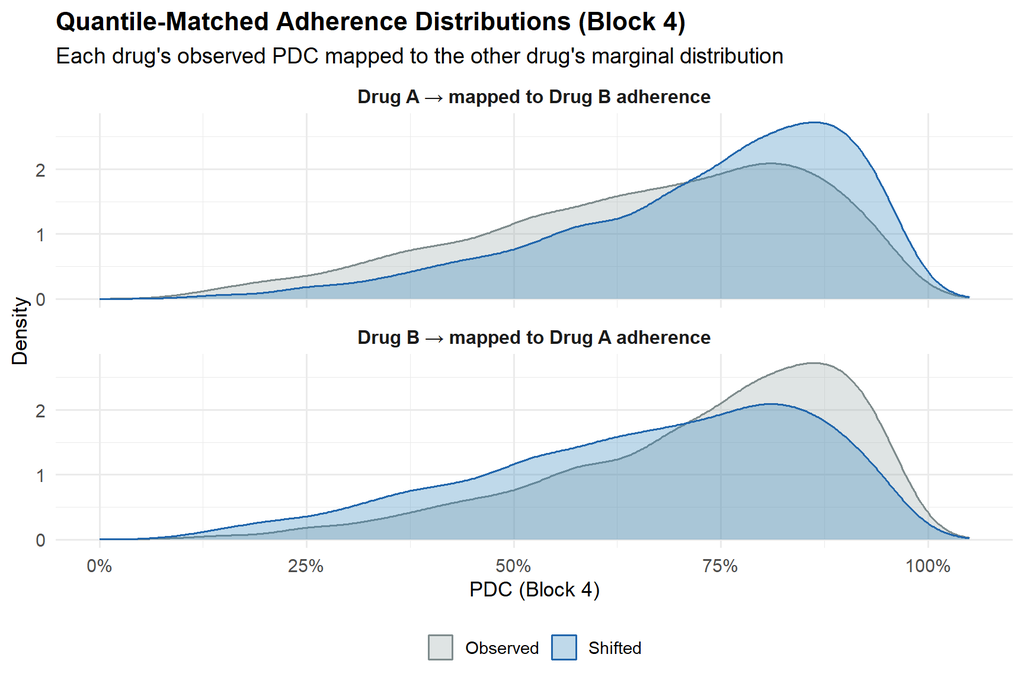

Figure 11: Quantile-matched adherence distributions at Block 4. Top: Drug A’s observed adherence shifted to match Drug B’s distribution. Bottom: Drug B’s observed adherence shifted to match Drug A’s distribution.